# Predição dos níveis de antígeno específico da próstata(psa)

Bruno Rafael Araújo Vasconcelos

4 de abril de 2016

## Introdução

Os níveis de psa no sangue indicam que o indivíduo está com câncer de próstata para valores acima de 4ng/ml. Existem vários fatores que podem estar ligados aos níveis de psa no sangue e alguma forma como por exemplo o volume do câncer. A pergunta báse de nossa pesquisa é “A partir de algum fator, é possível prever os níveis de psa no sangue do indivíduo?”.

Escolhemos alguns dados de exames de pacientes do sexo masculino afim de identificar câncer de próstata(veja aqui). Para cada valor em alguns fatores aplicamos O logaritmo para que os dados fossem melhor ajustados.

O sumário dos dados pode ser visto abaixo:

```
#vol: volume do câncer
#weight:  peso do paciente
#age: idade do paciente
#bph: hiperplasia prostática benigna
#svi: invasão das vesículas seminais
#cp: penetração capsular
#gleason: escore Gleason
#pgg45: percentagem escore Gleason 4 ou 5
#psa: antígeno específico da próstata (esta é a variável resposta).
```

Nosso objetivo nessa pesquisa é encontrar um modelo linear para prever os valores de níveis de psa( em inglês Prostate Specific Antigen) no sangue que é um dos indicadores do câncer de próstata (veja aqui).

A princípio, vamos calcular para cada par de variáveis (X, psa) o coeficiente de correlação de pearson e verificar o quanto cada fator influencia nos níveis de PSA. Como o fator que queremos analisar é o PSA teremos que o Y no par será sempre o PSA enquanto que X será qualquer um dos outros fatores.

## Coeficientes e Gráficos de correlação(R)

Nossa primeira meta é descobrir, através do coeficiente e dos gráficos de de correlação descobrir quais variáveis apresentam indícios de relação com os níveis de psa e então posteriormente trabalharmos encima delas para gerar um modelo de regressão validá-lo e regerar o modelo utilizando técnicas do método LASSO.

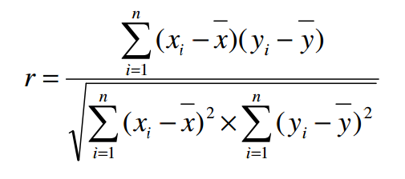

Quando o coeficiente de Pearson resulta em um valor próximo de -1 ou 1 temos relação forte entre os fatores. Quando ele está próximo de 0, há indícios de que os fatores não tem relação nenhuma. Se r resulta em um valor próximo de -1 há indícios de que há uma relação inversa entre as variáveis, isto é, são inversamente proporcionais. Se r resulta em um valor próximo de 1 dizemos que a relação é diretamente proporcional e quando os valores de uma cresce a outra cresce aproximadamente igual.

Abaixo mostramos um quadro com todos os valores r de cada par de fatores dos nossos dados

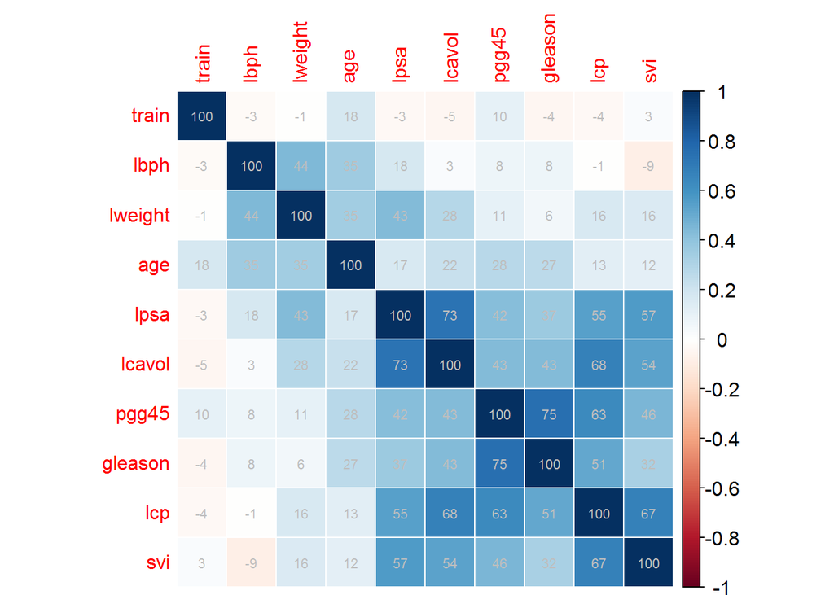

```r
cex.before <- par("cex")
par(cex = 0.7)
corrplot(cor(data), insig = "blank", method = "color",
         addCoef.col="grey",
         order = "AOE", tl.cex = 1/par("cex"),
         cl.cex = 1/par("cex"), addCoefasPercent = TRUE)
```

```r
par(cex = cex.before)
```

Após calcularmos os coeficientes de correlação, vamos visualizar melhor a relação entre as variáveis e o psa

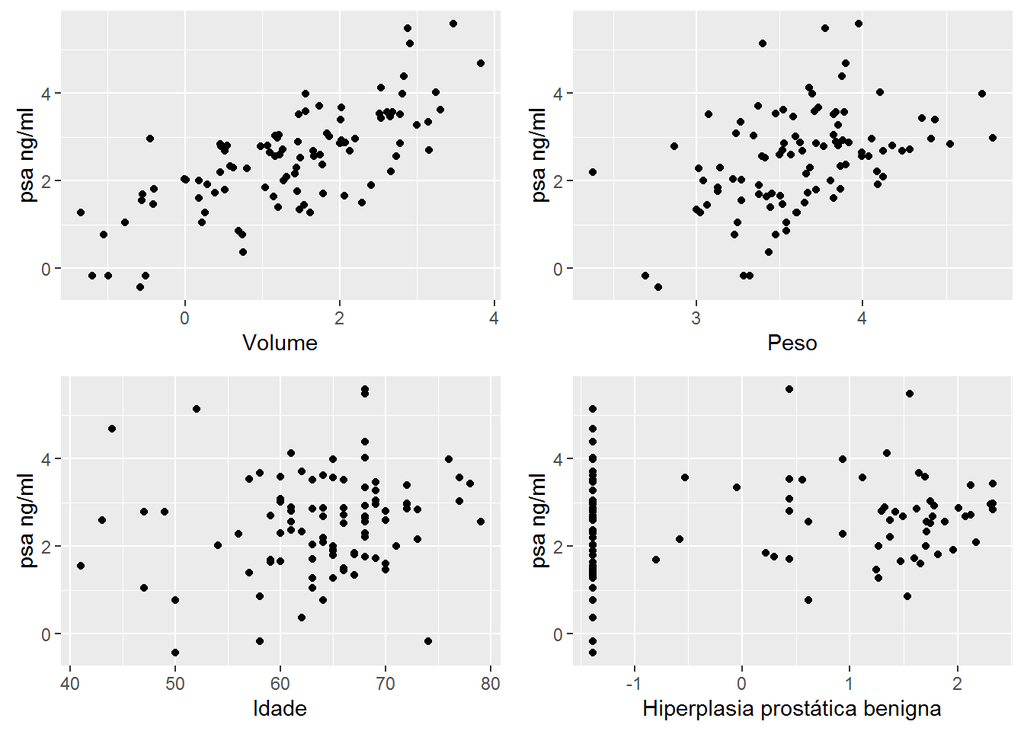

```r
grid.arrange(graph_vol, graph_weight, graph_age, graph_bph, ncol=2, nrow=2)
```

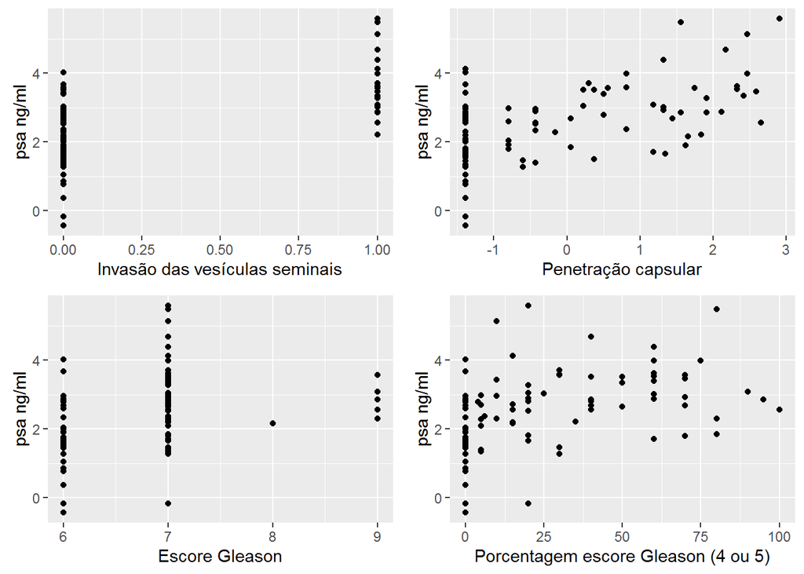

```r
grid.arrange(graph_svi, graph_lcp, graph_gleason, graph_pgg45, ncol=2, nrow=2)
```

## Construindo o modelo de regressão

O modelo de regressão foi construído baseado nos fatores que mais apresentaram ter influência no psa segundo os gráficos apresentados anteriormente e os coeficientes de correlação de cada par de fatores (X, psa). Os fatores relevantes, foram aqueles cujos seus coeficientes de correlação foram superior a 50%. Os fatores escolhidos foram o volume(lcavol), a invasão das vesículas seminais(svi) e a penetração capsular(cp). Com isso montamos o nosso modelo de regressão linear múltipla, com os fatores escolhidos

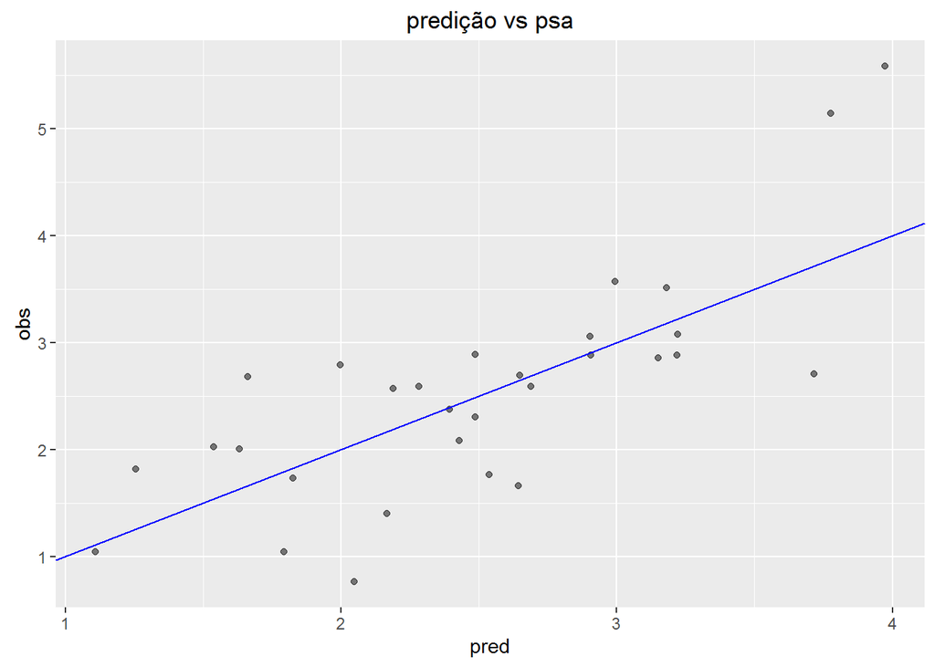

```r
regression_line <- lm(lpsa ~ lcavol+svi+lcp, data = data_training)
predictions <- predict(regression_line, select(data_test,lcavol, svi, lcp))
lm_predictions <- data.frame(pred = predictions, obs = data_test$lpsa)

ggplot(lm_predictions, aes(x = pred, y = obs)) + geom_point(alpha = 0.5, position = position_jitter(width=0.2)) + geom_abline(colour = "blue") + ggtitle("predição vs psa")
```

## Avaliação do modelo

Para avaliarmos o modelo, fizemos um gráfico comparativo entre os resíduos e os valores das predições

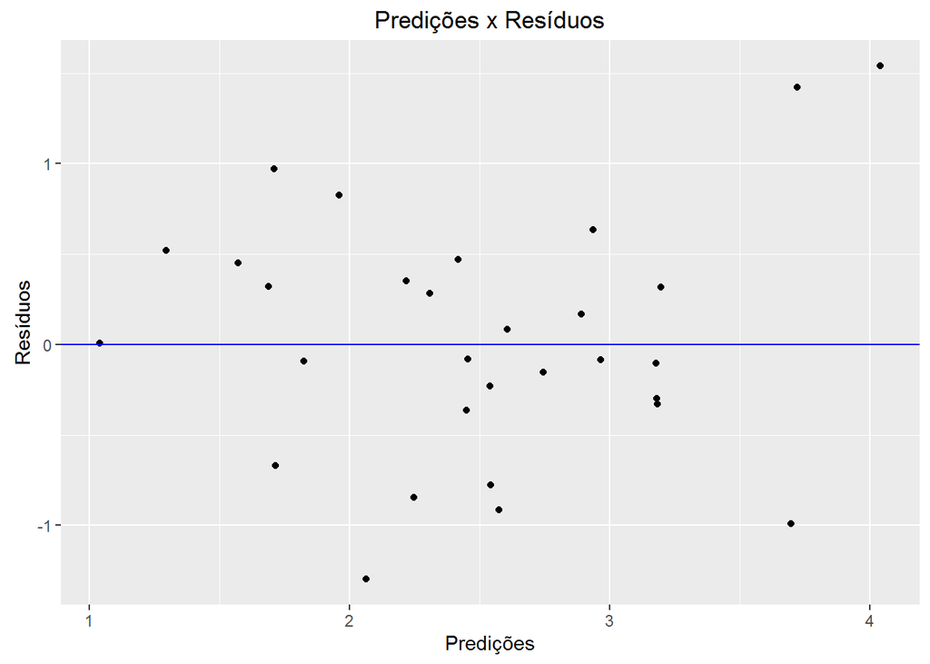

```r
trash <- data_test$lpsa - predictions
qplot(predictions, trash, ylab = "Resíduos", xlab = "Predições") + geom_hline(yintercept = 0, color='blue') + ggtitle("Predições x Resíduos")
```

e calculamos o valor do RMSE(Raiz do erro quadrático da média)

```r
RMSE(predictions, data_test$lpsa)
```

```
## [1] 0.6654602
```

Indicando um valor um pouco alto para os resíduos

## Criando um modelo usando a técnica LASSO

Vamos observar o modelo gerado com a técnica LASSO. Essa técnica é importante para verificarmos quais fatores mais influenciam nos resultadose ajustar um modelo ao formato “exato” dos dados.

Geramos um modelo usando essa técnica a partir do conjunto de dados de treino e usando o RMSE como métrica. O gráfico abaixo mostra a curva do modelo ajustado.

```r
lasso <- train(lpsa ~ ., data=select(data_training, lcavol, lweight, age, lbph, svi, lcp, gleason, pgg45, lpsa), method='lasso', metric='RMSE',tuneLength=10)
```

Calculando a importância dos fatores usando a técnica vemos que a o fator volume(lcavol) é o que mais influência no resultado.

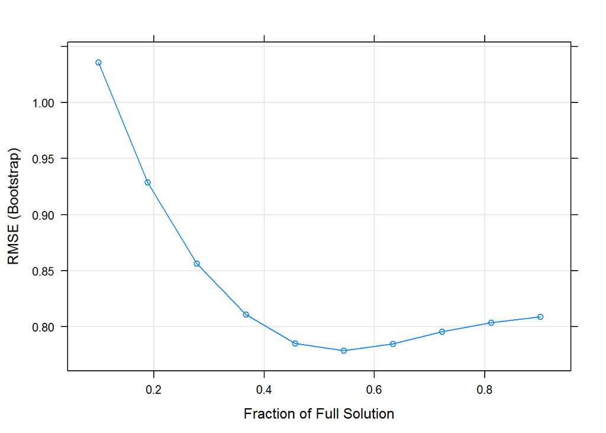

```r
plot(lasso)
```

E calculamos os valores preditores. Observe que agora precisamos encontrar o modelo usando todos os fatores, pois queremos saber qual a mais influente.

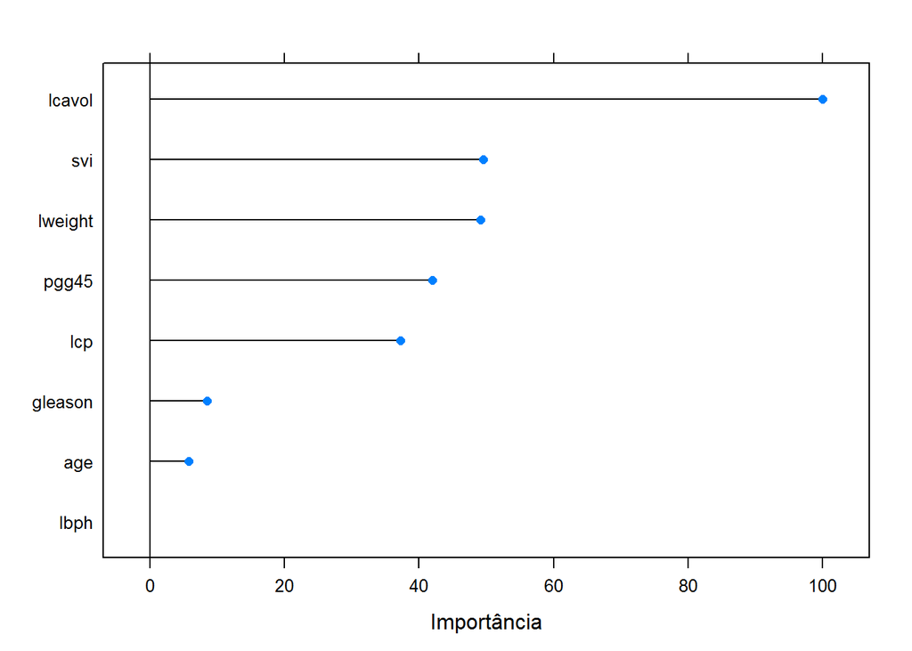

```r
plot(varImp(lasso), xlab = "Importância")
```

E comparamos com os valores observados

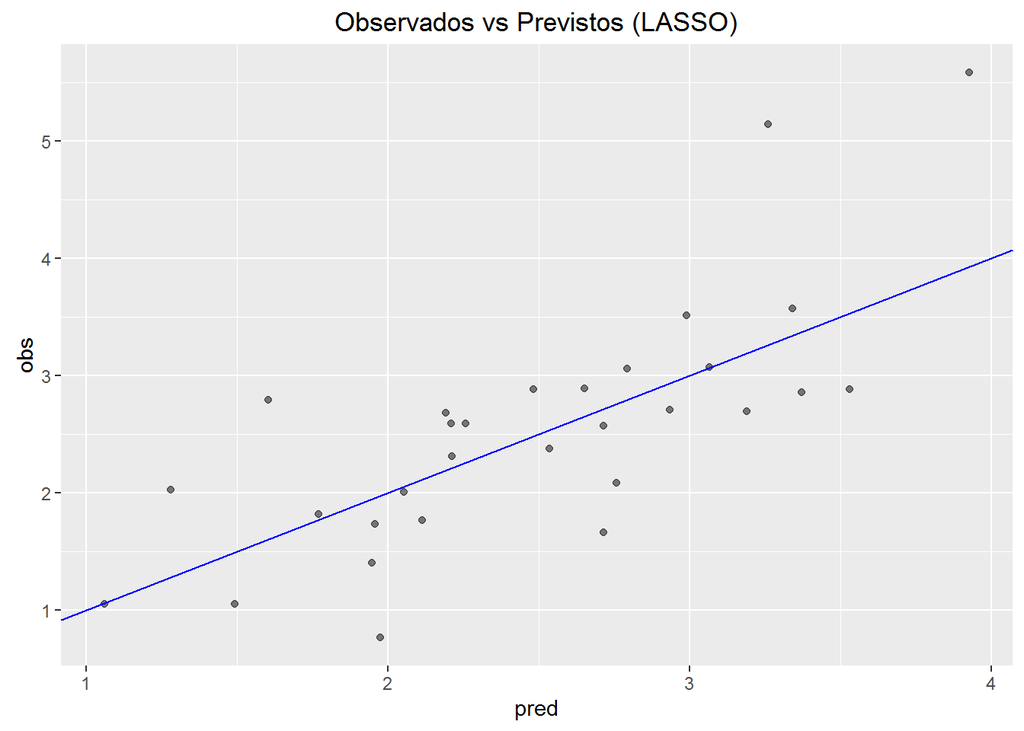

```r
lasso_predictions <- predict(lasso, select(data_test,lcavol, lweight, age, lbph, svi, lcp, gleason, pgg45))

la_predictions <- data.frame(pred = lasso_predictions, obs = data_test$lpsa)
ggplot(la_predictions, aes(x = pred, y = obs)) + geom_point(alpha = 0.5, position = position_jitter(width=0.2)) + geom_abline(colour = "blue") + ggtitle("Observados vs Previstos (LASSO)")
```

O RMSE do modelo usando LASSO é igual a

```r
RMSE(lasso_predictions, data_test$lpsa)
```

```
## [1] 0.6758323
```

E por fim podemos comparar os dois modelos

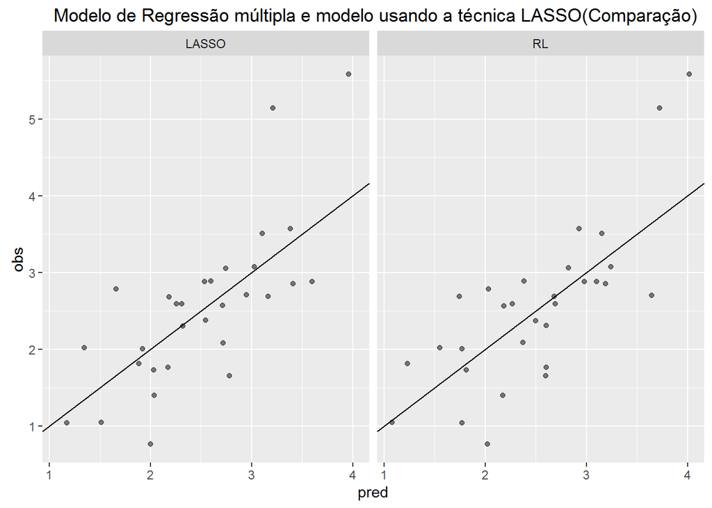

```r
compare <- lm_predictions
lm_predictions$model <- "RL"
la_predictions$model <- "LASSO"
compare <- rbind(lm_predictions, la_predictions)
ggplot(compare, aes(x = pred, y = obs)) +
  geom_point(alpha = 0.5, position = position_jitter(width=0.2)) +
  facet_grid(. ~ model) +
  geom_abline() +
  ggtitle(" Modelo de Regressão múltipla e modelo usando a técnica LASSO(Comparação)")
```

## Conclusão

Depois dos dados analisados e dos gráficos mostrados, podemos inferir que há indícios de que o câncer de próstata está ligado ao volume do câncer. O modelo apresentou um valor alto para o RMSE tanto na regressão múltipla quanto usando a técnica LASSO, o que indica que é um modelo não confiável. Não houve uma melhoria usando a técnica, os resultados obtidos através do modelo LASSO não foram precisos(o que é característica do modelo LASSO na maioria das vezes), o RMSE calculado para a a mostra foi alto. Outros fatores influenciaram o modelo de regressão, porém o volume do câncer apresentou uma maior correlação com os níveis de psa durante toda a análise dos dados. Portanto, se há uma variável que poderia explicar, os níveis de psa no sangue de um indíviduo é o volume do câncer, quanto maior, maior quantidade de psa o indivíduo terá no sangue.